# Prepare DOC data

Read raw data, clean it and compute averages per pixel.

Author

Thelma Panaïotis

```r
source("utils.R")
```

## Read data

```r
#|warning: false
# Read a first time to get column names
columns <- read_excel(
    "data/raw/0227166/4.4/data/0-data/All_Basins_Data_Merged_Hansell_2022.xlsx",
    n_max = 0
  ) %>%
  colnames() %>%
  tolower()

# Read a second time to get the data with the proper column names
df_doc_raw <- read_excel(
    "data/raw/0227166/4.4/data/0-data/All_Basins_Data_Merged_Hansell_2022.xlsx",
    skip = 2,
    col_names = columns
  )

# Select useful columns
df_doc <- df_doc_raw %>%
  select(
    bottle, bottle_flag_w,
    lon = longitude, lat = latitude, date,
    press = `ctd pressure`,
    doc, doc_flag_w
  )
```

## Clean

Remove aberrant doc observations (flag = 9, negative values…).

**TODO**

What values are ok for flags? Should we remove bottles that are `-999`?

```r
df_doc <- df_doc %>%
  filter(!date %in% c(-999, 0)) %>% # missing data
  filter(press != -999) %>% # missing depth
  filter(!bottle_flag_w %in% c(-999, 9)) %>% # bottle flag is ok
  filter(doc_flag_w != 9) %>% # flag is ok
  filter(doc > 0) %>% # doc is positive
  drop_na(doc) #%>% # drop missing values
 # mutate(date = ymd(date)) # format date
summary(df_doc)
```

```
     bottle       bottle_flag_w        lon               lat
 Min.   :  -999   Min.   :1.000   Min.   :-179.99   Min.   :-78.643
 1st Qu.:     7   1st Qu.:2.000   1st Qu.:-133.84   1st Qu.:-32.499
 Median :    16   Median :2.000   Median : -35.85   Median : 15.383
 Mean   :  1510   Mean   :2.201   Mean   : -28.34   Mean   :  6.568
 3rd Qu.:    26   3rd Qu.:2.000   3rd Qu.:  65.12   3rd Qu.: 40.334
 Max.   :168365   Max.   :5.000   Max.   : 213.60   Max.   : 89.988
 NA's   :2598
      date              press             doc           doc_flag_w
 Min.   : 2013031   Min.   :   0.0   Min.   : 13.30   Min.   :0.000
 1st Qu.:20050207   1st Qu.:  89.9   1st Qu.: 40.33   1st Qu.:2.000
 Median :20110330   Median : 399.5   Median : 45.20   Median :2.000
 Mean   :20046567   Mean   : 998.9   Mean   : 52.00   Mean   :2.003
 3rd Qu.:20150622   3rd Qu.:1442.1   3rd Qu.: 56.75   3rd Qu.:2.000
 Max.   :20210813   Max.   :6903.9   Max.   :724.75   Max.   :6.000
```

There is also a little cleaning to do with dates: the TRACERS (2013) cruise reported dates as `201303X` , but after inspecting boat trajectory (available at https://www.bco-dmo.org/dataset/549090) and comparing with DOC sampling location, it appears that those dates should be `2013030X`.

Moreover, some dates are `YYYYMM00`, let’s change them to `YYYYMM01`.

Let’s fix this.

```r
df_doc <- df_doc %>%
  mutate(
    date = as.character(date),  # convert date to character to split it
    # Fix for Tracers 2013
    date = ifelse( # if only 7 characters in date, one character is missing, add a 0 before the last character
      nchar(date == 7),
      paste0(str_extract(date, "^[[:digit:]]{6}"), "0", str_extract(date, "[[:digit:]]{1}$")),
      date
      ),
    # Fix for dates ending in 00
    date = str_replace(date, "00$", "01"),
    date = ymd(date) # format date
  )
```

## Assign observations to layers

```r
df_doc <- df_doc %>%
  mutate(layer = case_when(
    press <= surface_bottom ~ "surf",
    press > surface_bottom & press <= meso_top ~ "epi",
    press > meso_top & press <= meso_bottom ~ "meso",
    press > meso_bottom ~ "bathy",
  )) %>%
  filter(!is.na(layer)) # drop observations not assigned to any layer
```

## Average by pixel across the layers

### Annual

```r
df_doc_ann <- df_doc %>%
  mutate(
    # floor and add 0.5 because other env data are on the centre of each pixel
    lon = roundp(lon, precision = 1, f = floor) + 0.5,
    lat = roundp(lat, precision = 1, f = floor) + 0.5
  ) %>%
  group_by(lon, lat, layer) %>%
  summarise(
    # compute mean and sd
    doc_mean = mean(doc),
    doc_sd = sd(doc),
    n_obs = n(),
    .groups = "drop"
  )
```

Let’s plot some maps.

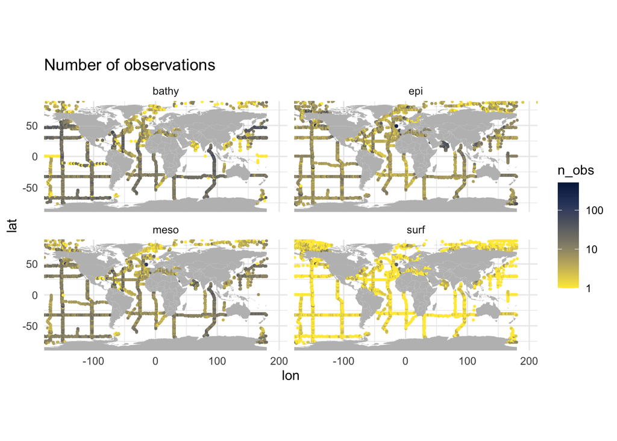

```r
# Number of observations
ggmap(df_doc_ann, "n_obs", type = "point", palette = ggplot2::scale_colour_viridis_c(option = "cividis", trans = "log10", direction = -1)) +
  ggtitle("Number of observations") +
  facet_wrap(~layer, ncol = 2)
```

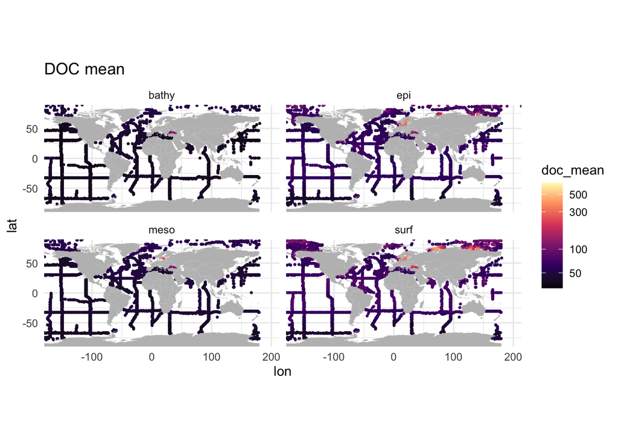

```r
# DOC mean
ggmap(df_doc_ann, "doc_mean", type = "point", palette = ggplot2::scale_colour_viridis_c(option = "A", trans = "log10")) +
  ggtitle("DOC mean") +
  facet_wrap(~layer, ncol = 2)
```

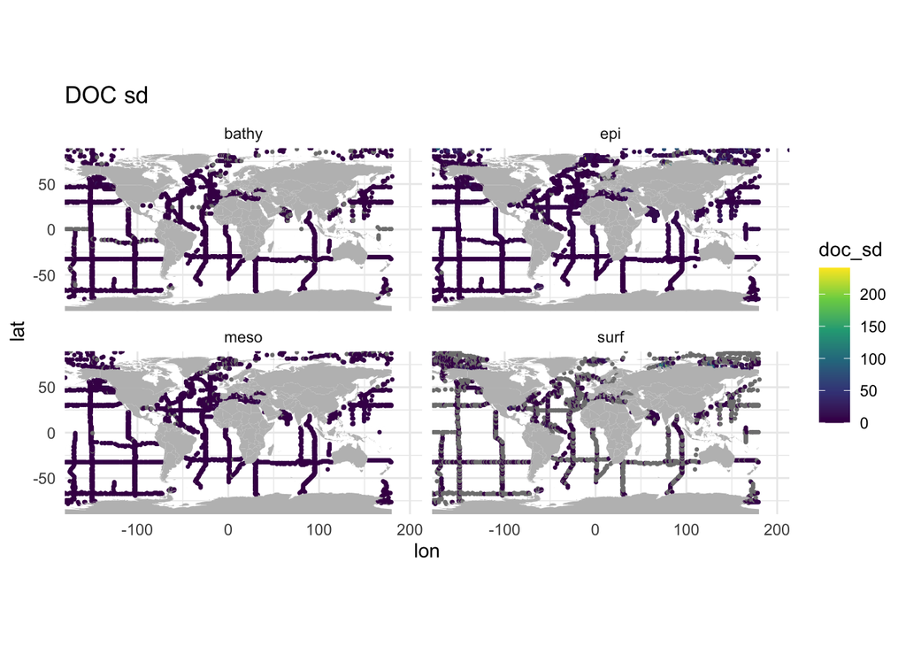

```r
# DOC sd
ggmap(df_doc_ann, "doc_sd", type = "point", palette = ggplot2::scale_colour_viridis_c()) +
  ggtitle("DOC sd") +
  facet_wrap(~layer, ncol = 2)
```

Store layered doc in multiple columns, in a similar fashion as for env data, and add season.

```r
df_doc_ann <- df_doc_ann %>%
  select(lon, lat, layer, doc = doc_mean) %>%
  mutate(layer = paste0("doc.", layer)) %>%
  pivot_wider(names_from = layer, values_from = doc) %>%
  mutate(season = 0, .after = lat)
```

### Seasonal (surface layer only)

Seasons are defined as:

- season 1 = DJF
- season 2 = MAM
- season 3 = JJA
- season 4 = SON

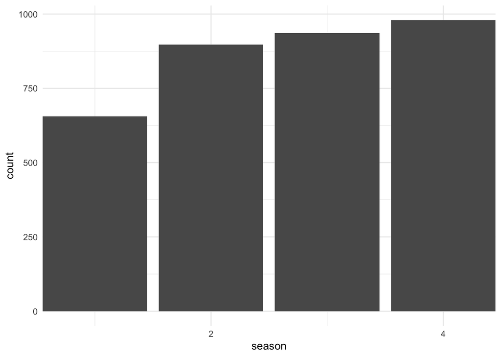

```r
df_doc_s <- df_doc %>%
  filter(layer == "surf") %>%
  mutate(season = quarter(date, fiscal_start = 12)) %>%
  # generate seasonal average by pixel
  mutate(
    # floor and add 0.5 because other env data are on the centre of each pixel
    lon = roundp(lon, precision = 1, f = floor) + 0.5,
    lat = roundp(lat, precision = 1, f = floor) + 0.5
  ) %>%
  group_by(lon, lat, season) %>%
  summarise(
    # compute mean and sd
    doc.surf = mean(doc),
    .groups = "drop"
  )

# Counts per season
ggplot(df_doc_s) + geom_bar(aes(x = season)) + scale_x_continuous(n.breaks = 3, expand = c(0,0))
```

And plot seasonal maps.

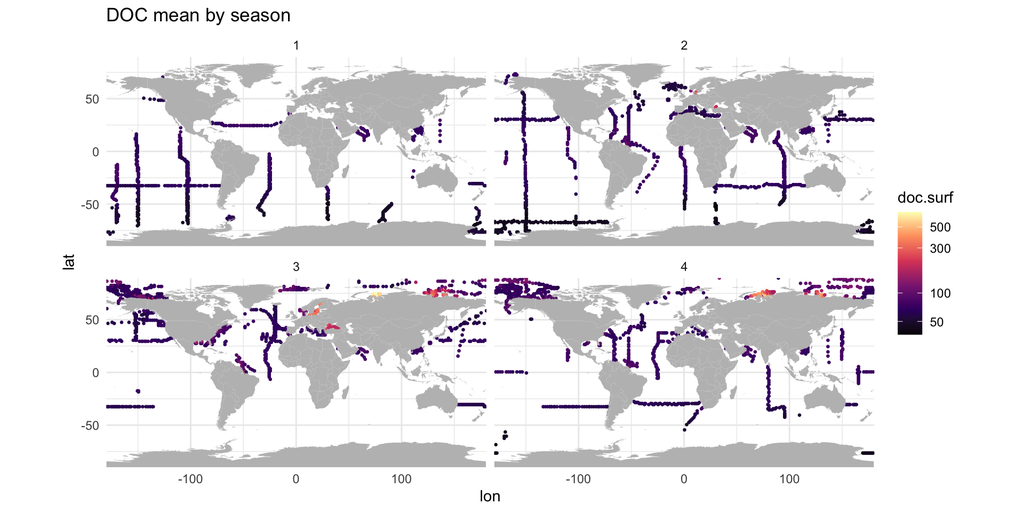

```r
ggmap(df_doc_s, "doc.surf", type = "point", palette = ggplot2::scale_colour_viridis_c(option = "A", trans = "log10")) +
  facet_wrap(~season) +
  ggtitle("DOC mean by season")
```

Few observations during winter at high latitudes. Will see what we can do.

## Save DOC data

```r
# Join annual and seasonnal observations together
df_doc <- bind_rows(df_doc_ann, df_doc_s)

### Some sanity checks
## seasonal data is only in surf #ok
#df_doc %>% filter(season != 0) %>% select(-contains(c("meso", "bathy"))) %>% summary()
#df_doc %>% filter(season != 0) %>% select(contains(c("meso", "bathy"))) %>% summary()
#
## annual data is in all 3 layers
#df_doc %>% filter(season == 0) %>% summary()
#
## All ok!


# Save
save(df_doc, file = "data/01.doc_data.Rdata")
```